# Study of contraceptive method prediction model in Indonesia

Harry Chan

updated: 2022-01-22

## 0.1 Exercise 1: Audience Personas

Crystal is an undergraduate computer science student interested in machine learning. She has taken courses in machine learning. She is curious about any kinds of problem machine learning could be a viable solution to and how technology can benefit the general public.

## 0.2 Exercise 2: Write your report

The Github repo: https://github.com/harryyikhchan/contraceptive_method_predictor  
The Online PDF Report: https://github.com/harryyikhchan/contraceptive_method_predictor/blob/main/doc/contraceptive_method_predictor_report.pdf

# 1 Abstract

Access to contraceptive options is fundamental to empower women to take charge of their own health, enabling them to make informed decisions about family planning. But barriers to access to contraceptives still exists in most developing countries. In this study, we built a classification model using the SVC classifier algorithm which can help predict the use/or no use contraceptives by women based on their demographic and socio-economic characteristics. The data used in our project was a subset of 1987 National Indonesia Contraceptive Prevalence Survey. 1473 samples were selected from the original samples and all samples are married women who were either not pregnant or do not know if they were at the time of interview.

When evaluating the training set, the RBF SVC classifier showed the best cross-validation score. Similarly, when evaluating the test set, the overall accuracy of the model was 74% and the area under the curve (AUC) was of 78%. Therefore, it can be conducted that RMB SVC is the most suitable model for this classification problem given that the data-set provided. However given that this model had moderate amount of false predictions for the no-use of contraceptive method, further work to improve model prediction was needed before we could put this model in the real world.

# 2 Introduction

Family planning offers immediate health benefits, potential non-health benefits that encompass expanded education opportunities and empowerment for women as well as economic advancement. Consequently, the proportion of women of reproductive age who are in need for modern contraceptive methods has increased gradually from 73.6 percent in 2000 to 76.8 percent in 2020 (Economic and Affairs 2020). Reasons for the slow growth may arise from lack of access to services, poor quality of available services, gender barriers and personal bias against some methods. These limitations are not addressed in some regions due to their cultural/traditional beliefs, financial background, religious influence, etc.

In last two decades, decision tree-based and multivariate regression-based prediction models have received some attention in the study of family planning, but it generally exhibit modest predictive performance, especially for certain large and complicated datasets (T. Lim, Loh, and Cohen). Machine learning (ML) such as SVC can improve the performance by exploiting large data repositories to identify novel predictors and non-linear interactions between them.

In this study, we conducted a prediction model research based on a specific background in Indonesia. The objective is to predict whether the contraceptive method is used by Indonesian women based on their demographic and socio-economic factors. In 1991, a dataset were taken from the 1987 National Indonesia Contraceptive Prevalence Survey and a cohort of 1473 samples were selected.

# 3 Methods

## 3.1 Data Collection

The Indonesian Central Bureau of Statistics conducted the survey from September to December 1987 to collect information on sociodemographic status (ethnicity, education level, financial status, occupation, marital status, religious belief and so on). Interviews were conducted with 11,884 ever-married women age 15-49, from a sample of households representing 93 percent of the population of Indonesia.

## 3.2 Ethics Approval

The study entailed secondary analyis of data containing no personal identifying information. The participants were informed about the objectives and methods of the study. They were informed that their participation was totally voluntary and that they could withdraw from the study at any time without citing any reason. Written and signed or thumb printed informed consent was obtained from those who agreed to participate, or from their guardians.

## 3.3 Data Pre-Processing

### 3.3.1 Summary of the dataset

Exploratory data analysis was performed on the training data-set and was found to have no missing values. Table 1 shows the description of the attributes of this dataset. The attribute `Contraceptive method used` was taken as a target variable, and the ermaining eight attributes were taken as feature variables.

Table 3.1: Summary of the dataset

| Column name | Description | Type | Values |
| --- | --- | --- | --- |
| Wife age | Wife’s age | Numberical | any positive values |
| Wife education | Wife’s education | Categorical | 1=low, 2, 3, 4=high |
| Husband education | Husband’s education | Categorical | 1=low, 2, 3, 4=high |
| Number of children even born | Number of children evern born | Numberical | any positive values |
| Wife religion | Wife’s religion | Binary | 0=Non-Islam, 1=Islam |
| Wife now working | Is wife working or not | Binary | 0=Yes, 1=No |
| Husband occupation | Husband’s occpation | Categorical | 1,2 ,3 ,4 |
| Standard-of-living index | Standard-of-living Index | Categorical | 1=low, 2, 3, 4=high |
| Media Exposure | Media exposure | Binary | 0=Good, 1=Not good |
| Contraceptive method used | Contraceptive method used | Categorical | 1=No-use, 2=Long-term, 3=Short-term |

### 3.3.2 Distribution of the target class

There are three classes in this dataset - with 1 (“No-use”), 2 (“Long-term use”), followed by 3 (“Short-term use”). In this study, we aimed to examine whether the women would use any contraceptive methods. Therefore, we have combined 2 and 3 as “use” case and have left 1 as it is (“no-use” case). After the transformation, the distribution of the classes: `0 = No-use`: 636 observations, `1 = use`: 837 observations.

### 3.3.3 Data Transformation

Based on the EDA (Exploratory Data Analysis) performed earlier and variable descriptions, there were no missing values in the dataset. However, the variables were of different data types. In order to perform operations on data, the consistency of data types should be guaranteed. Feature scaling (Standardization) was performed on the numeric data while integer-encoding were done for the ordinal categorical features. The following table shows different variables in the data-set and the respective transformation performed on each of them.

Table 3.2: Transformation of the variable

| Data Type | Variable | Transformation | Technique used |
| --- | --- | --- | --- |
| Numerical | Wife’s age, Number of children evern born | Scaling | Standarization |
| Ordinal | Wife’s education, Husband’s education | Encoding | Integer Encoding |
| Ordinal | Husband’s occpation, Standard-of-living Index | Encoding | Integer Encoding |
| Binary | Wife’s religion, Is wife working or not, Media exposure | None | Pass through |

## 3.4 Data Analysis

### 3.4.1 Model Selection

We have explored the following four Machine Learning classifier algorithms to predict the target feature:

1. Decision Tree
2. kNN
3. Logistic Regression
4. RBF SVC

### 3.4.2 Train-Test Split

Data sampling was not required as the original data-set was not a significantly larger one. As shown below, the model has been trained and tuned on 1031 rows of training data and tested on 442 rows of test data. This was constituted from 70:30 ratio of training vs test observations in the dataset.

### 3.4.3 Model Evaluation

To measure the performance of the model we used the area under the receiver operating characteristics (ROC) curve (AUC or AUROC). 10-fold cross validation has been used as the model evaluation strategy. Accuracy results are presented as mean SD calculated over the tenfold validation sets.

### 3.4.4 Cross Validation Results

Table 3.3: Cross Validation Result

| X | decision.tree | kNN | Logistic.Regression | RBF.SVM |
| --- | --- | --- | --- | --- |
| fit_time | 0.01 | 0.01 | 0.03 | 0.04 |
| score_time | 0.01 | 0.01 | 0.01 | 0.02 |
| test_score | 0.63 | 0.65 | 0.66 | 0.69 |
| train_score | 0.99 | 0.77 | 0.68 | 0.75 |

### 3.4.5 Hyperparameter Tuning

The randomized search for hyperparameter tuning of each classifiers has been performed via cross-validation approach. Given that the performance of RBF SVC was the best, we applied hyper-parameter tuning and experiment with the pre-defined hyperparmeters in a total of 200 iterations to find the optimal parameters. In each iteration, we compute the validation accuracy. A dictionary for the hyperparameters of the RBF SVC classifier is defined as below:

- value range for “gamma”: Between -3 and 4 on a log scale
- value range for “C”: Between -2 and 6 on a log scale
- values for `class_weight`: None, Balanced

Among all of the combination of the hyperparameters, we settled for the combination of hyperparameter `gamma = 0.01, C = 10, class_weight = None`. The results of the top 5 models are shown in the table below.

Table 3.4: Hyperparameter Selection

| X | X1 | X2 | X3 | X4 | X5 |
| --- | --- | --- | --- | --- | --- |
| mean_test_score | 0.70 | 0.70 | 7e-01 | 0.70 | 0.69 |
| param_svc__gamma | 0.01 | 0.00 | 1e-02 | 0.01 | 0.10 |
| param_svc__C | 10.00 | 1000.00 | 1e+03 | 100.00 | 10.00 |
| param_svc__class_weight | NA | NA | NA | NA | NA |
| mean_fit_time | 0.21 | 0.15 | 4e-01 | 0.17 | 0.19 |

# 4 Results

## 4.1 Confusion Matrix

The accuracy of the machine learning algorithm can be calculated from the confusion matrix. In the abstract term, the confusion matrix is given below. Here, FP = False Positive, FN = False, Positive, TN = True Negative, and TP = True Positive. Accuracy, Recall, Precision and F-measure were used to calculate the performance measurement of the classification.

|  | Predicted Not Use (0) | Predicted Use (1) |
| --- | --- | --- |
| Actually Not Use (0) | TN | FP |
| Actually Use (1) | FN | TP |

The confusion matrix of RBF SVC classifier for test set is shown in the figure 1.

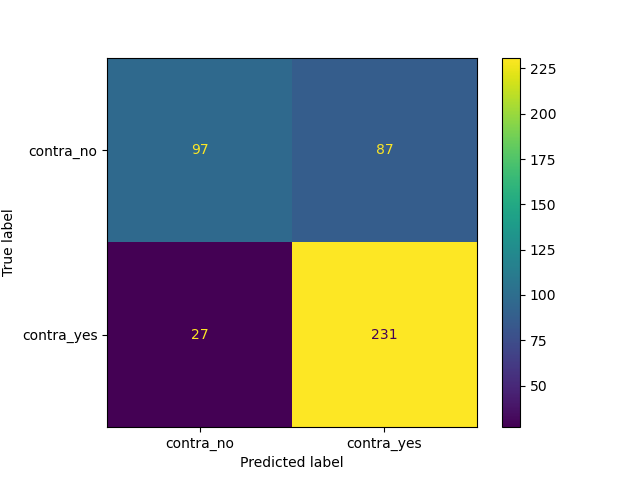

Figure 4.1: Confusion Matrix (Actual vs Predicted)

We have considered the use of contraceptive method as positive class. The findings of Confusion Matrix suggested that the model preformed well on the total number of `True positives` i.e 231 which were the ones that the model predicted correctly to be using contraceptive method.and `True Negatives` i.e 97 which were predicted correctly for not using contraceptive method.

However, it was found that there were some false positives and false negatives. `False positives` were indicated when the model affirmatively predicted the use of contraceptive method when in fact, the person did not use contraceptives i.e in our matrix 87 .and `False Negatives` indicated when the model incorrectly predicted the person was not using, when they did not use contraceptives.

## 4.2 Scoring Metric

The recall, precision and the f1-score were calculated while considering each class to be the positive class. Our findings showed that the recall value was approximately **0.90**, indicating a better true positive rate (TPR) for the `1` class and **0.53**, indicating the TPR of the `0` class. The accuracy and weight average accuracy obtained were 74% and 73% respectively.

Table 4.1: Scoring Metrics

| X | precision | recall | f1.score | support |
| --- | --- | --- | --- | --- |
| contra_no | 0.78 | 0.53 | 0.63 | 184 |
| contra_yes | 0.73 | 0.90 | 0.80 | 258 |
| accuracy | NA | NA | 0.74 | NA |
| macro avg | 0.75 | 0.71 | 0.72 | 442 |
| weighted avg | 0.75 | 0.74 | 0.73 | 442 |

## 4.3 ROC Curve

As mentioned above, the ROC curves were plotted at a threshold of $0.5$. In order to obtain an overall score for our model, the Area under the curve was observed which resulted in a decent score of 78% from the figure 2: AUC ROC Curve.

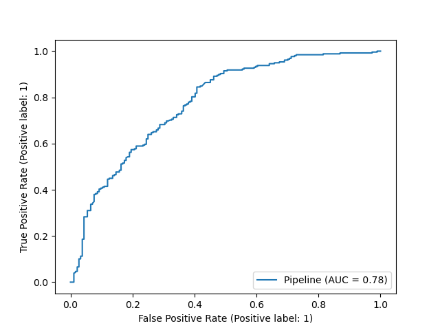

Figure 4.2: AUC ROC Curve

# 5 Conclusion

The process intended to predict the use of contraceptives in married women based on their socio-economic and demographic information. In the process, 4 different models were tried. In our study, the best model RMB SVC performed well given the size of the data-set with an accuracy of $74\%$ , `recall` of $90\%$, `precision` of $73\%$ , `f1_score` of $80\%$ and `AUC` $78\%$. The precision indicates, that out of all predicted positives, how many are positive, i.e. out of 100 predicted positive samples, 73 were using the contraceptives. High Recall indicated, out of total positives how many were predicted positive A high recall showed that our model could identify most of them correctly. These results were in line with the validation scores outlined previously. The result of high `recall value` of $90\%$ also indicated that `False Negatives` were very low and showed an appreciable f1_score of 0.8.

Since the size of the data set was significantly small (only 1473), the accuracy rate of the models developed could be considered low to represent the entire county (Indonesia). Also, this dataset could be a biased one, considering its small size of it. As a well-known limitation of the supervised machine learning is that it requires a large number of data to achieve a reasonably accurate model. Therefore, if a larger data set is available for this exercise, then a more accurate model could have been developed. In opposed to supervised machine learning, deep learning would have been a better approach for this kind of problem with limited data sets. There is room to improve the model in future by considering more parameters and more ensemble methods during the hyperparameter tuning process.

# 6 Acknowledgment

This data-set is a subset of the 1987 National Indonesia Contraceptive Prevalence Survey . It was sourced from the UCI Machine Learning Repository.

The Python programming languages (Van Rossum and Drake Jr 1995) and the following Python packages were used to perform the analysis: altair (VanderPlas et al. 2018), docopt (de Jonge 2018), matplotlib (Hunter 2007), numpy (Harris et al. 2020), pandas (McKinney et al. 2010), sckit-learn (Pedregosa et al. 2011). The code used to perform the analysis and create this report can be found [here](https://github.com/harryyikhchan/contraceptive_method_predictor).

# References

de Jonge, Edwin. 2018. *Docopt: Command-Line Interface Specification Language*. https://CRAN.R-project.org/package=docopt.

Dua, Dheeru, and Casey Graff. 2017. “UCI Machine Learning Repository.” University of California, Irvine, School of Information; Computer Sciences. http://archive.ics.uci.edu/ml.

Economic, United Nations Department of, and Social Affairs. 2020. “World Family Planning 2020 Highlights.” 2020. https://www.un.org/development/desa/pd/sites/www.un.org.development.desa.pd/files/files/documents/2020/Sep/unpd_2020_worldfamilyplanning_highlights.pdf.

Harris, Charles R., K. Jarrod Millman, Stéfan J van der Walt, Ralf Gommers, Pauli Virtanen, David Cournapeau, Eric Wieser, et al. 2020. “Array Programming with NumPy.” *Nature* 585: 357–62. https://doi.org/10.1038/s41586-020-2649-2.

Hunter, John D. 2007. “Matplotlib: A 2d Graphics Environment.” *Computing in Science & Engineering* 9 (3): 90–95.

Lim, Tjen-sien, Wei-yin Loh, and W. Cohen. “A Comparison of Prediction Accuracy, Complexity, and Training Time of Thirty-Three Old and New Classification Algorithms.” In *Machine Learning*, 2000.

Lim, Tjen-Sien, Wei-Yin Loh, and Yu-Shan Shih. 2000. “A Comparison of Prediction Accuracy, Complexity, and Training Time of Thirty-Three Old and New Classification Algorithms.” *Machine Learning* 40 (3): 203–28.

McKinney, Wes et al. 2010. “Data Structures for Statistical Computing in Python.” In *Proceedings of the 9th Python in Science Conference*, 445:51–56. Austin, TX.

Pedregosa, Fabian, Gaël Varoquaux, Alexandre Gramfort, Vincent Michel, Bertrand Thirion, Olivier Grisel, Mathieu Blondel, et al. 2011. “Scikit-Learn: Machine Learning in Python.” *Journal of Machine Learning Research* 12 (Oct): 2825–30.

Van Rossum, Guido, and Fred L Drake Jr. 1995. *Python Tutorial*. Centrum voor Wiskunde en Informatica Amsterdam, The Netherlands.

VanderPlas, Jacob, Brian Granger, Jeffrey Heer, Dominik Moritz, Kanit Wongsuphasawat, Arvind Satyanarayan, Eitan Lees, Ilia Timofeev, Ben Welsh, and Scott Sievert. 2018. “Altair: Interactive Statistical Visualizations for Python.” *Journal of Open Source Software* 3 (32): 1057.